# 01 Introdución al Muestreo

FES Acatlán

agosto de 2021

## Introducción

¿Dónde se usa el muestreo?

- Encuestas de INEGI (Ingreso-Gasto, Población económicante activa, etc)
- Estudios de Mercado
- Control de calidad

Ejemplos particulares son: nivel de escolaridad en una ciudad, nivel de desempleo, la opinión de un producto, elecciones de partidos políticos, etc.

## Objetivo del muestreo

Conocer las características generales de una población.

¿Qué debe cumplir una buena muestra?.

Deseamos que sea una muestra representativa, es decir, que la variable de interés presente una distribución semejante a la población.

Lo anterior nos lleva apreguntarnos por un tamaño de muestra ‘apropiado’. A veces erroneamente se cree que un tamaño de muestra del 10% de tu población es apropiado.

**Ejercicio**. Pensar un ejemplo donde un tamaño menor al 10% sea representativo y otro ejemplo donde un 10% no sea suficiente.

El tamaño de muestra depende de los siguientes factores:

- La **variabilidad** de lo que queremos estudiar.
- La **presición** con la que queremos hacer inferencia.
- El **tamaño** de la población.
- El **presupuesto** que tengamos.

## Definición de Conceptos

- ¿Qué es una población?

Conjunto completo de observaciones que se desea estudiar. La población se define al especificar que elementos son y que características deben tener. Los elementos de la población pueden ser personas, viviendas, escuelas, etc. ejemplo, todas las escuelas primarias de la CDMX.

- Marco de muestreo.

Listado que contiene las unidades de muestreo. Ejemplo, una lista de telefonos de un call center. Muchas veces no es sencillo obtener el marco muestral.

- ¿Qué es una muestra?

Es un subconjunto de la población. Son elementos seleccionados del marco muestral.

- UPM (unidad primaria de muestreo).

Son las unidades que seleccionamos en una muestra. Ejemplo, nos interesa estudiar el ingreso de las personas en una colonia, pero por conveniencia seleccionamos hogares o viviendas de la colonia y ntrevistamos a las personas de esas viviendas seleccionadas.

## Tipos de muestra

- No probabilistica
  - A juicio. Se usa el criterio experto del investigador.
  - Por cuotas. Es realizada por un entrevistador y se les solicita a cada entrevistador cubrr una cuota de encuestas.
- Probabilística
  - Muestreo aleatorio simple
  - Estratificado
  - conglomerados

Las muestras no probabilisticas suelen ser útiles en algunas situaciones para dar una idea general, no obstante, se puede incurrir en sesgos y no se puede evaluar la confiabilidad de los resultados.

En el muestreo probabilísico se selecciona a los elementos de la población con probabilidades conocidas y mayores a cero.

¿Por qué son tan populares las muestras probabilísticas?

Porque permiten calcular:

- Estimadores insesgados
- Errores estandar
- Intervalos de confianza

**Ejercicio**. Comenta ejemplos de malas prácticas que consideres podrían ocurrir en el levantamiento de encuestas.

## Fuentes de error

**Sesgo de selección**

Ocurre cuando alguna parte de la población objetivo no está en en la población muestreada. Una muestra grande no asegura que se tenga sesgo pequeño.

**Sesgo de medición**

Este tipo de sesgo puede darse por:

- Las personas no siempre dicen la verdad (ingresos / uso de drogas). pueden dar respuestas correctas sin intención como el parentezco con cierto familiar.
- Los entrevistadores registran mal las respuestas.
- Se puede afectar la precisión de las respuestas al dar un todo específco a una pregunta o la forma de redacción de la misma.
- Diferencias culturaes. Una palabra puede siignificar cosas disyintas en ciertas regiones.

Este tipo de errores puede ser controlado poniendo mayor dedicacción a la construcción del cuestionario y a la capacitación del trabajo de campo.

**Error muestral**

Contrario a las fuentes anteriores, este error puede ser medido utilizando métodos estadísticos y por lo tanto hay opciones para disminuirlo o controlarlo con el diseño de la muestra.

## Pasos para realizar una encuesta por muestreo

1. Establecimiento de objetivos
2. Definición de la población
3. Marco
4. Diseño de la muestra
5. Método de medición
6. Instrumento de medición
7. Prueba piloto
8. Organización de trabajo en campo
9. Manejo de la información
10. Análisis de datos

## Propiedades deseables de un Estimador

**Estimador**. Es una función de la la muestra que no tiene involucrados parámetros desconocidos y se construye para estimar un parámetro de la población. Nota, este valor varia de muestra a muestra.

**Estimación**. Es el valor que toma el estimador una vez observados los valores de la muestra.

**Distribución muestral**. Es la función de distribución de un estimador.

`Ejercicio.` Dar 3 ejemplos de funciones de distribución y su uso. Para un repaso de funciones de distribución se puede consultar el libro *Hassets, Stewart. Probability for Risk Management*.

Ejemplo sencillo. se tienen 6 individuos a los cuales se les midió cierta característica

```r
individuos <- c("individuo1","individuo2","individuo3","individuo4","individuo5","individuo6")
caracteristica <- c(0,1,2,3,4,5)

tabla <- data.frame(individuos,caracteristica)
tabla
```

```
##   individuos caracteristica
## 1 individuo1              0
## 2 individuo2              1
## 3 individuo3              2
## 4 individuo4              3
## 5 individuo5              4
## 6 individuo6              5
```

Considerando estos individuos como nuestra población, el promedio de la carácteristica es

$$\bar{X} = \frac{\sum x_{i}}{n} = \frac{15}{6} = 2.5$$

Ahora, con una muestra de tamaño 2 se desea estimar el promedio. Si se selecciona una muestra aleatoria de tal manera que cualquier muestra de tamaño 2 tenga la misma probabilidad de ser seleccionada, ¿Cuántas muestra posibles hay?

$${6 \choose 2} = \frac{6!}{2!4!} = 15$$

Podemos calcularlas a mano (lo que sería muy ineficiente a medida que el tamaño de nuestra población crece) o podemos tomar ventaja de las herramientas ya desarrolladas.

La función combn nos permite generar las combinaciones. Por practicidad lo haremos directamente sobre la caraterística, pero notra que también se podría hacer para los individuos y después manipular la tabla previa.

```r
combinaciones <- combn(caracteristica,2)
combinaciones
```

```
##      [,1] [,2] [,3] [,4] [,5] [,6] [,7] [,8] [,9] [,10] [,11] [,12] [,13]
## [1,]    0    0    0    0    0    1    1    1    1     2     2     2     3
## [2,]    1    2    3    4    5    2    3    4    5     3     4     5     4
##      [,14] [,15]
## [1,]     3     4
## [2,]     5     5
```

```r
tabla_combinaciones <- data.frame(t(combinaciones))
tabla_combinaciones
```

```
##    X1 X2
## 1   0  1
## 2   0  2
## 3   0  3
## 4   0  4
## 5   0  5
## 6   1  2
## 7   1  3
## 8   1  4
## 9   1  5
## 10  2  3
## 11  2  4
## 12  2  5
## 13  3  4
## 14  3  5
## 15  4  5
```

El procedimiento de selección aleatorio implica que cualquiera de las muestras tiene la misma probabilidad de ser seleccionada, es decir, no se favorece más una muestra sobre las otras. En este caso, cada muestra aleatoria de tamaño 2 tiene porobabilidad $\frac{1}{15}$

Con los valores de cada muestra podemos obtener la distribución muestral del estimador

```r
estimaciones <- tabla_combinaciones %>% mutate(promedio = (X1+X2)/2)
estimaciones
```

```
##    X1 X2 promedio
## 1   0  1      0.5
## 2   0  2      1.0
## 3   0  3      1.5
## 4   0  4      2.0
## 5   0  5      2.5
## 6   1  2      1.5
## 7   1  3      2.0
## 8   1  4      2.5
## 9   1  5      3.0
## 10  2  3      2.5
## 11  2  4      3.0
## 12  2  5      3.5
## 13  3  4      3.5
## 14  3  5      4.0
## 15  4  5      4.5
```

Ditribución muestral

```r
total <- dim(estimaciones)[1]
distribucion_muestral <- estimaciones %>%
                          group_by(promedio) %>%
                          summarise(frecuencia = n(), frecuencia_relativa = frecuencia / total)
distribucion_muestral
```

```
## # A tibble: 9 x 3
##   promedio frecuencia frecuencia_relativa
##      <dbl>      <int>               <dbl>
## 1      0.5          1              0.0667
## 2      1            1              0.0667
## 3      1.5          2              0.133
## 4      2            2              0.133
## 5      2.5          3              0.2
## 6      3            2              0.133
## 7      3.5          2              0.133
## 8      4            1              0.0667
## 9      4.5          1              0.0667
```

Generemos el histograma de la distribución muestral.

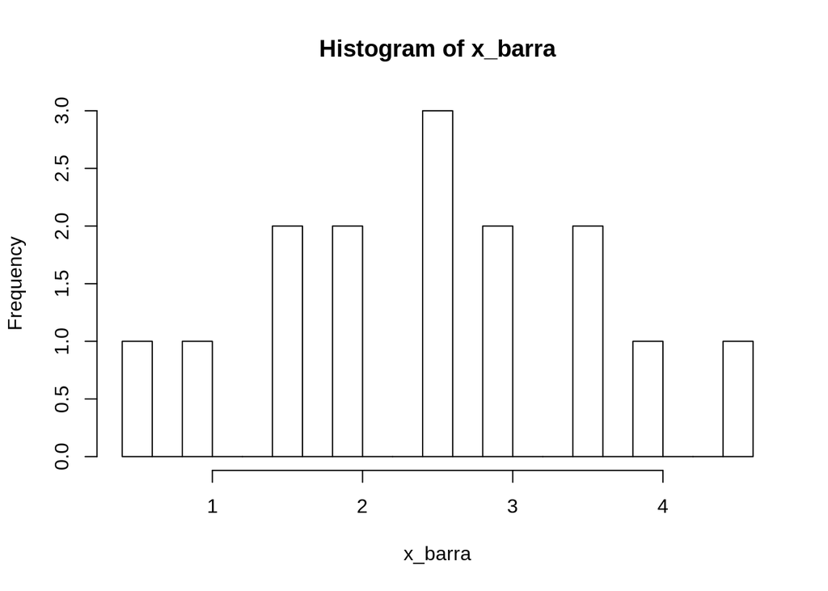

```r
# Extraer la variable promedio y que el objeto sea un vector
x_barra <- estimaciones %>% select(promedio) %>% pull()

# Graficar de forma sencilla
hist(x_barra, breaks = 15)
```

**Recomendación**. Para viasualización de datos la siguiente referencia es muy buena, se centra en como presentar los datos de manera adecuada. *Cole Nussbaumer. Storytelling with Data*.

La siguiente figura ilustra distintos valores que pueden tomar los estimadores.

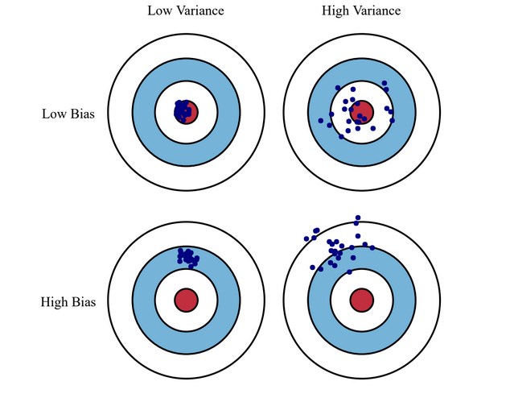

Estimadores

Las propiedades deseables para nuestros estimadores son:

- **unbiashed** (insesgado). Esto es, es que el promedio de los valores que puede tomar coincida con el verdadero valor del parámetro, es decir, la esperanza del del estimador sea el parámetro.

$$E(\hat{\theta}) = \theta$$

- **precise** (preciso). Esto es, si la varianza del estimador es pequeña.

$$V(\hat{\theta}) = E[{(\hat{\theta} - E(\hat{\theta}))}^2]$$

- **accurate** (exacto). Esto es, si su error cuadratico medio (MSE por sus siglas en inglés) es pequeño.

$$MSE(\hat{\theta}) = E[{(\hat{\theta} - \theta)}^2]$$

Se puede probar que

$$MSE(\hat{\theta}) = V(\hat{\theta}) + {Sesgo(\hat{\theta})}^2$$

Nota.
$$Sesgo(\hat{\theta}) = E(\hat{\theta}) - \theta$$

Estas propiedades no son exclusivas del muestreo, también aplican a modelos predictivos. Dado que nuestras estimaciones pueden tener error de sesgo y varianza, usualmente se busca minimizar el **mse**.

[figure not shown]

overfitting

## Teorema del Límite Central

Sea $x_{1}, x_{2}, ... , x_{n}$ una muestra aleatoria de una función de dstribución con media $\mu$ y varianza $\sigma^{2}$ y sea $\bar{x} = \frac{\Sigma x_{i}}{n}$ para n suficientemente grande, se tiene que $\bar{x}$ se distribuye :

$$N(\mu,\frac{\sigma^2}{n})$$

Vemos que la varianza se ve afectada por el tamaño $n$. Así, mientras más grande el tamaño de $n$, La varianza será menor.

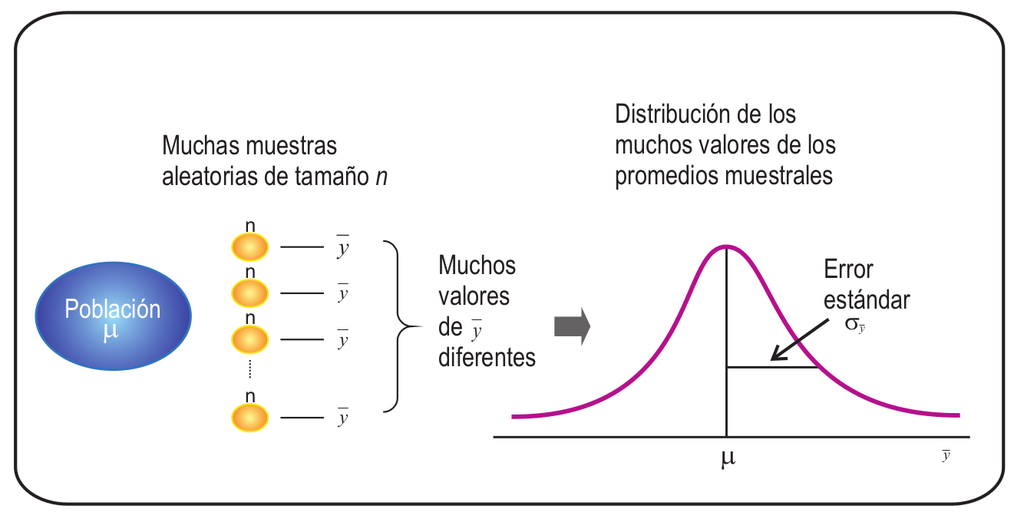

TLC1

Podemos estar interesados en hacer inferencia sobre muchos distintos indicadores de una población, no obstante, historicamente el principal desarrollo de la teoría de muestreo ha sido estimar promedios y totales, es por ello que nos es útil el teorema central del límite.

Se ha establecido empíricamente la velocidad de convergencia a la distribución normal dependiendo de la distribución de la variable de interés de la población.

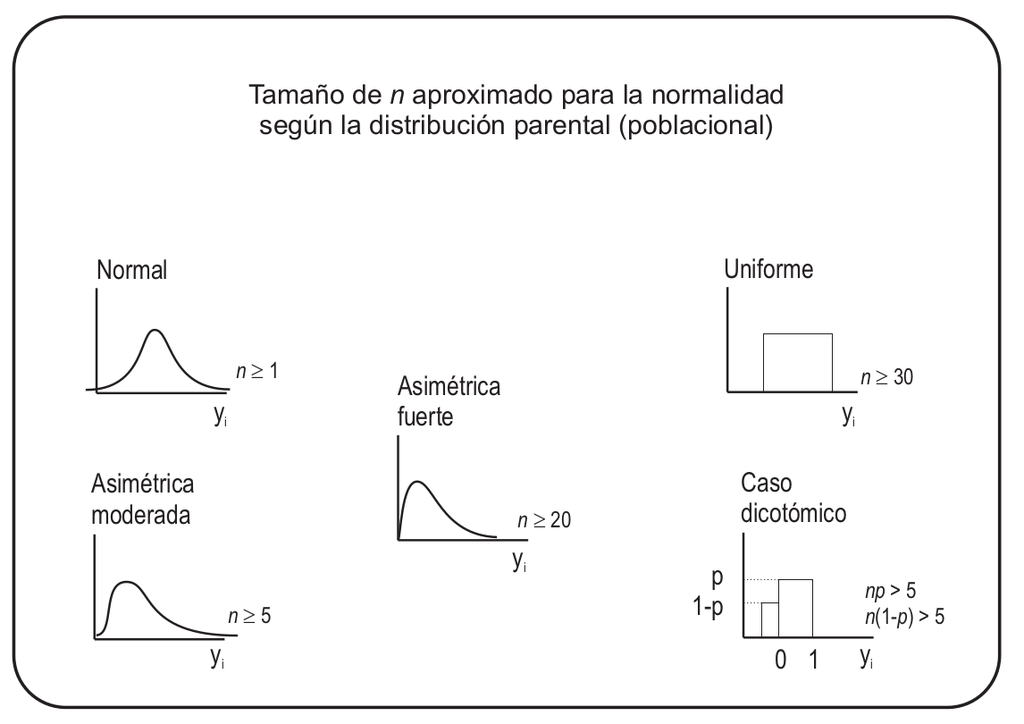

TLC2

**Ejercicio**. Mediante simulación, crear la distribución muestral de la media para ejemplificar el teorema central del límite.

Pasos. a) Generar datos de una distribución uniforme. (Graficar para corroborar). b) obtener k muestras aleatorias de los datos generados en a) (hint, se puede usar la función sample). c) a cada muestra del paso b) calcular su promedio. d) tendremos k promedios, graficar un histograma de esos k promedio.

Pregunta. ¿Qué pruebas existen para validar si una distribución es normal?

**Extra** ¿Qué debe cumplir un generador de número aleatorios para considerarse un buen generador?